# Lab 5

### QUESTION 14:

##### What happens if, instead of using Scheffe(7) we resort to Bonferroni on a fine grid of ages, e.g. every whole month.Do we get significant results? Is this a reasonable approach?

```
##      std  Bonf.80    Sch.7
## 1.959964 3.420527 3.750619
```

```
##                 coef        se      Ustd  UBonf.80    USch.7       Lstd
## g(0.417)  0.30616513 1.2575895 2.7709952  4.607784  5.022904 -2.1586650
## g(0.583)  0.24053301 0.9783411 2.1580463  3.586975  3.909917 -1.6769803
## g(1.17)   0.08030809 0.4927859 1.0461507  1.765895  1.928560 -0.8855345
## g(2.08)   0.43374794 0.4284344 1.2734640  1.899219  2.040642 -0.4059681
## g(2.83)   1.64017869 0.4766433 2.5743824  3.270550  3.427886  0.7059750
## g(3.42)   1.62199320 0.5414774 2.6832693  3.474131  3.652868  0.5607171
## g(4.75)  -0.33167518 0.5890600 0.8228613  1.683220  1.877664 -1.4862116
## g(6.17)   1.33346058 1.4469307 4.1693927  6.282726  6.760346 -1.5024715
## g(6.42)   1.80374084 1.9784855 5.6815013  8.571203  9.224286 -2.0740196
## g(6.83)   2.64494011 3.0824610 8.6864526 13.188580 14.206076 -3.3965723
##              LBonf.80     LSch.7
## g(0.417) -3.995453286 -4.4105735
## g(0.583) -3.105908851 -3.4288514
## g(1.17)  -1.605279179 -1.7679438
## g(2.08)  -1.031723412 -1.1731462
## g(2.83)   0.009807566 -0.1475286
## g(3.42)  -0.230144584 -0.4088819
## g(4.75)  -2.346570740 -2.5410147
## g(6.17)  -3.615804629 -4.0934249
## g(6.42)  -4.963721790 -5.6168040
## g(6.83)  -7.898699902 -8.9161955
```

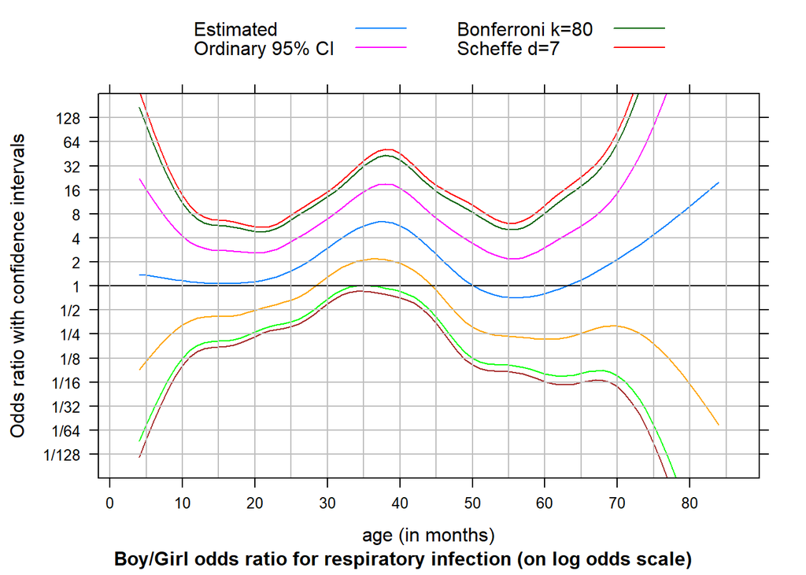

```r
xyplot( coef + Ustd + UBonf.80 + USch.7 + Lstd  + LBonf.80 +  LSch.7  ~ age,
        dmult,
        type = 'l',
        ylim = log( 2^c(-8,8)),
        scale = list(
          y = list(
            at =  log( 2^seq(-7,7,1)), labels = fractions( 2^seq(-7,7,1))),
          x = list( at = seq( 0,90,10))),

        sub = "Boy/Girl odds ratio for respiratory infection (on log odds scale)",
        ylab = "Odds ratio with confidence intervals",
        xlab = "age (in months)",
        panel = function(x,y,...) {
          panel.superpose(x,y,...)
          panel.abline( h = log( 2^seq(-7,7,1)), col = 'gray')
          panel.abline( h = 0)
          panel.abline( v = seq(0,90,5), col = 'gray')
        },
        auto.key = list( text = c('Estimated','Ordinary 95% CI',
                                  "Bonferroni k=80", "Scheffe d=7"),
                         lines = T, points = F, columns = 2)
        )
```

### QUESTION 14:

Add lmer to the comparison matrix. # Does lmer look closer to glmmPQL or to glmmML? # Plot the profile of coefs, sds and zs superposed for each method # What patterns emerge? #

##### I could not run fitlmer <- lmer( resp ~ sp(age.year) * Sex + time + Season + height_for_age + (1|id), data = ind, family = binomial)

##### due to errors, I am still working on the solution.